# Project: European Soccer Dataset Analysis

##### Table Of Content

- Introduction
- Wrangling
- Analysis
- Limitations & Conclusions

## Introduction

### Dataset Description

This soccer database contains data for soccer matches, players, and teams from several European countries from 2008 to 2016.

### Analysis scope

> Firs We Will Focus On Top Teams To Atchive Wins In Each Season and Their Attributes

> Next We Will Get The Total Goals That Teams Score Home and Away and See Who is a Candidate to Win?

> LastWe Will Get The Top 10 Attributes Of Top Players

## Data Wrangling

> First We Will Work On Understanding Our Data And Preper It For Analysis

```python
#loading important packages
import pandas as pd
import numpy as np
import matplotlib.pyplot as plt
%matplotlib inline
import seaborn as sns
import glob
```

```python
# Shawing Tables Names
print ('Tables We Will Be Working With : ')
print()
for file in glob.glob('Database_Soccer/*.csv'):
    print (file[16:-4], end="    ")
```

```
Tables We Will Be Working With :

Match    Player_Attributes    Country    Team_Attributes    sqlite_sequence    Player    Team    League
```

> Here we have 8 tabels and will explore and prepare them for analysis

```python
#creating lists to save files names and dirs
files = []
path = []
for file in glob.glob('Database_Soccer/*.csv'):
    path.append(file)
    files.append(file[16:-4])
for ind,df in enumerate(files): #looping in files list to rename it to be used in creating DataFrames
    files[ind] = '{}_df'.format(df.lower())
```

```python
# Creating DataFrames with Tabels names
for index,df in enumerate(files):
    exec(f'{df} = pd.read_csv(path[index])')
```

```python
match_df.head(1)
```

|  | id | country_id | league_id | season | stage | date | match_api_id | home_team_api_id | away_team_api_id | home_team_goal | ... | SJA | VCH | VCD | VCA | GBH | GBD | GBA | BSH | BSD | BSA |
| --- | --- | --- | --- | --- | --- | --- | --- | --- | --- | --- | --- | --- | --- | --- | --- | --- | --- | --- | --- | --- | --- |
| 0 | 1 | 1 | 1 | 2008/2009 | 1 | 2008-08-17 00:00:00 | 492473 | 9987 | 9993 | 1 | ... | 4.0 | 1.65 | 3.4 | 4.5 | 1.78 | 3.25 | 4.0 | 1.73 | 3.4 | 4.2 |

1 rows × 115 columns

```python
match_df.isna().sum()
```

```
id                      0
country_id              0
league_id               0
season                  0
stage                   0
date                    0
match_api_id            0
home_team_api_id        0
away_team_api_id        0
home_team_goal          0
away_team_goal          0
home_player_X1       1821
home_player_X2       1821
home_player_X3       1832
home_player_X4       1832
home_player_X5       1832
home_player_X6       1832
home_player_X7       1832
home_player_X8       1832
home_player_X9       1832
home_player_X10      1832
home_player_X11      1832
away_player_X1       1832
away_player_X2       1832
away_player_X3       1832
away_player_X4       1832
away_player_X5       1832
away_player_X6       1832
away_player_X7       1832
away_player_X8       1832
                    ...
B365H                3387
B365D                3387
B365A                3387
BWH                  3404
BWD                  3404
BWA                  3404
IWH                  3459
IWD                  3459
IWA                  3459
LBH                  3423
LBD                  3423
LBA                  3423
PSH                 14811
PSD                 14811
PSA                 14811
WHH                  3408
WHD                  3408
WHA                  3408
SJH                  8882
SJD                  8882
SJA                  8882
VCH                  3411
VCD                  3411
VCA                  3411
GBH                 11817
GBD                 11817
GBA                 11817
BSH                 11818
BSD                 11818
BSA                 11818
Length: 115, dtype: int64
```

> This table has alot of fituers but to our questions we will focus on season, homa and away teams goals that Luckily has no missing values

```python
player_attributes_df.head(1)
```

|  | id | player_fifa_api_id | player_api_id | date | overall_rating | potential | preferred_foot | attacking_work_rate | defensive_work_rate | crossing | ... | vision | penalties | marking | standing_tackle | sliding_tackle | gk_diving | gk_handling | gk_kicking | gk_positioning | gk_reflexes |
| --- | --- | --- | --- | --- | --- | --- | --- | --- | --- | --- | --- | --- | --- | --- | --- | --- | --- | --- | --- | --- | --- |
| 0 | 1 | 218353 | 505942 | 2016-02-18 00:00:00 | 67.0 | 71.0 | right | medium | medium | 49.0 | ... | 54.0 | 48.0 | 65.0 | 69.0 | 69.0 | 6.0 | 11.0 | 10.0 | 8.0 | 8.0 |

1 rows × 42 columns

```python
player_attributes_df.isna().sum()
```

```
id                        0
player_fifa_api_id        0
player_api_id             0
date                      0
overall_rating          836
potential               836
preferred_foot          836
attacking_work_rate    3230
defensive_work_rate     836
crossing                836
finishing               836
heading_accuracy        836
short_passing           836
volleys                2713
dribbling               836
curve                  2713
free_kick_accuracy      836
long_passing            836
ball_control            836
acceleration            836
sprint_speed            836
agility                2713
reactions               836
balance                2713
shot_power              836
jumping                2713
stamina                 836
strength                836
long_shots              836
aggression              836
interceptions           836
positioning             836
vision                 2713
penalties               836
marking                 836
standing_tackle         836
sliding_tackle         2713
gk_diving               836
gk_handling             836
gk_kicking              836
gk_positioning          836
gk_reflexes             836
dtype: int64
```

> We can see here that there are some missing data we will see if droping them affect our data

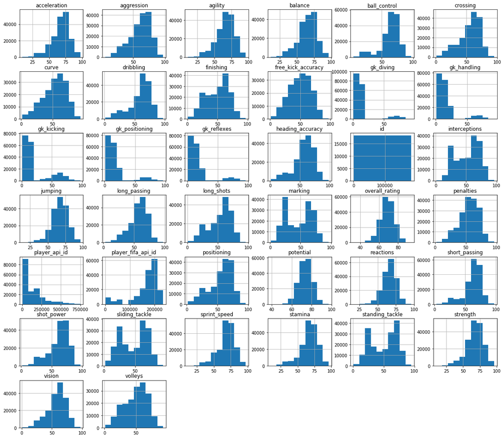

```python
player_attributes_df.hist(figsize=(20,18));
```

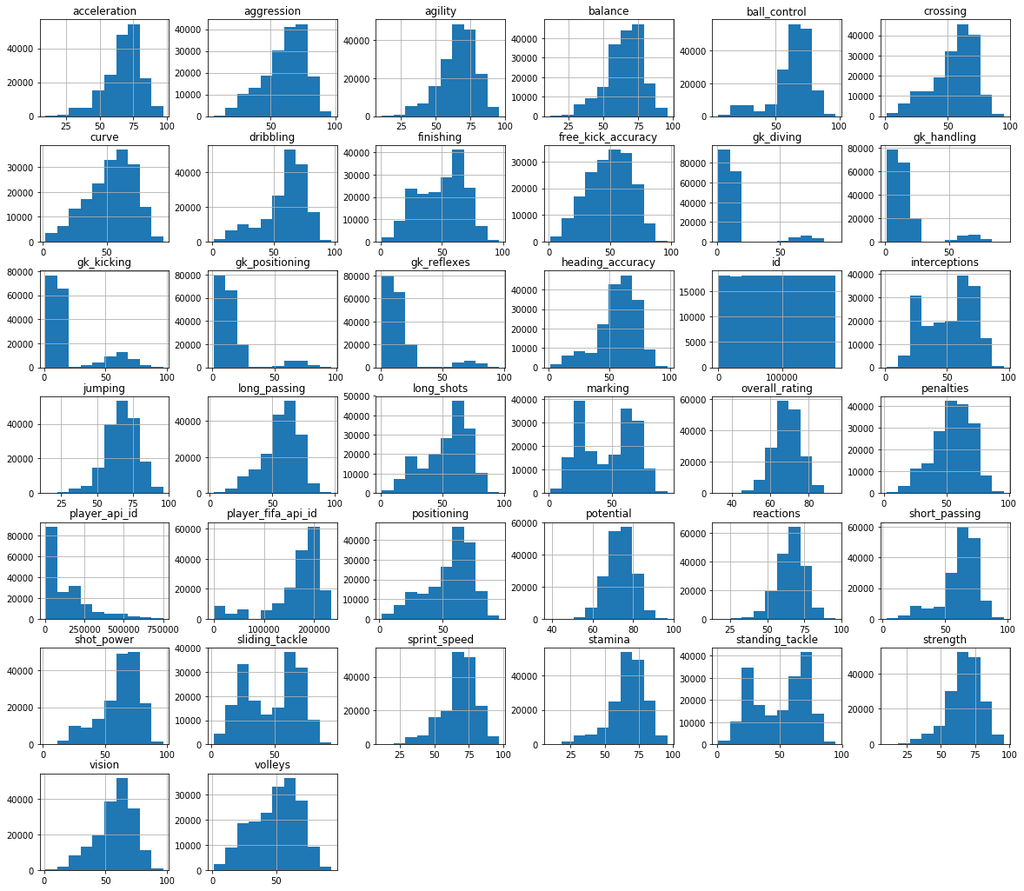

```python
player_attributes_df.dropna().hist(figsize=(20,18));
```

```python
player_attributes_df = player_attributes_df.dropna()
```

> I see that droping missing data will not affect our data so I droped it

> This table has alot of wondrful players attributes, we will work on get the top players most important attributes later

```python
country_df.head()
```

|  | id | name |
| --- | --- | --- |
| 0 | 1 | Belgium |
| 1 | 1729 | England |
| 2 | 4769 | France |
| 3 | 7809 | Germany |
| 4 | 10257 | Italy |

```python
country_df.isna().sum()
```

```
id      0
name    0
dtype: int64
```

```python
team_attributes_df.head(1)
```

|  | id | team_fifa_api_id | team_api_id | date | buildUpPlaySpeed | buildUpPlaySpeedClass | buildUpPlayDribbling | buildUpPlayDribblingClass | buildUpPlayPassing | buildUpPlayPassingClass | ... | chanceCreationShooting | chanceCreationShootingClass | chanceCreationPositioningClass | defencePressure | defencePressureClass | defenceAggression | defenceAggressionClass | defenceTeamWidth | defenceTeamWidthClass | defenceDefenderLineClass |
| --- | --- | --- | --- | --- | --- | --- | --- | --- | --- | --- | --- | --- | --- | --- | --- | --- | --- | --- | --- | --- | --- |
| 0 | 1 | 434 | 9930 | 2010-02-22 00:00:00 | 60 | Balanced | NaN | Little | 50 | Mixed | ... | 55 | Normal | Organised | 50 | Medium | 55 | Press | 45 | Normal | Cover |

1 rows × 25 columns

```python
team_attributes_df.isna().sum()
```

```
id                                  0
team_fifa_api_id                    0
team_api_id                         0
date                                0
buildUpPlaySpeed                    0
buildUpPlaySpeedClass               0
buildUpPlayDribbling              969
buildUpPlayDribblingClass           0
buildUpPlayPassing                  0
buildUpPlayPassingClass             0
buildUpPlayPositioningClass         0
chanceCreationPassing               0
chanceCreationPassingClass          0
chanceCreationCrossing              0
chanceCreationCrossingClass         0
chanceCreationShooting              0
chanceCreationShootingClass         0
chanceCreationPositioningClass      0
defencePressure                     0
defencePressureClass                0
defenceAggression                   0
defenceAggressionClass              0
defenceTeamWidth                    0
defenceTeamWidthClass               0
defenceDefenderLineClass            0
dtype: int64
```

> This table sounds good and has alot of good teams attributes and that attribute that have the missing value we will not work with in our analysis so there is no matter to drop them

```python
sqlite_sequence_df.head()
```

|  | name | seq |
| --- | --- | --- |
| 0 | Team | 103916 |
| 1 | Country | 51958 |
| 2 | League | 51958 |
| 3 | Match | 51958 |
| 4 | Player | 11075 |

```python
player_df.head(1)
```

|  | id | player_api_id | player_name | player_fifa_api_id | birthday | height | weight |
| --- | --- | --- | --- | --- | --- | --- | --- |
| 0 | 1 | 505942 | Aaron Appindangoye | 218353 | 1992-02-29 00:00:00 | 182.88 | 187 |

```python
player_df.isna().sum()
```

```
id                    0
player_api_id         0
player_name           0
player_fifa_api_id    0
birthday              0
height                0
weight                0
dtype: int64
```

```python
team_df.head(1)
```

|  | id | team_api_id | team_fifa_api_id | team_long_name | team_short_name |
| --- | --- | --- | --- | --- | --- |
| 0 | 1 | 9987 | 673.0 | KRC Genk | GEN |

```python
team_df.isna().sum()
```

```
id                   0
team_api_id          0
team_fifa_api_id    11
team_long_name       0
team_short_name      0
dtype: int64
```

> Sounds like we will work with team_api_id not team_fifa_api_id when get teams names and of course I will not drop these values

```python
league_df.head(1)
```

|  | id | country_id | name |
| --- | --- | --- | --- |
| 0 | 1 | 1 | Belgium Jupiler League |

```python
league_df.isna().sum()
```

```
id            0
country_id    0
name          0
dtype: int64
```

> I think our data is clean now and ready for ansewr our qusetions.

> But these are alot of merge need to be done so I prefer to merge when need

> In The below Cells We Will Get Top Teams To Atchive Wins

```python
match_df.info()
#alot of columns here we will take a few of them next
```

```
<class 'pandas.core.frame.DataFrame'>
RangeIndex: 25979 entries, 0 to 25978
Columns: 115 entries, id to BSA
dtypes: float64(96), int64(9), object(10)
memory usage: 22.8+ MB
```

```python
#getting cloumns indexes to cut the dataframe
columns = match_df.columns
for column in columns:
    index = columns.get_loc(column)
    print(column,'---> index:',index)
```

```
id ---> index: 0
country_id ---> index: 1
league_id ---> index: 2
season ---> index: 3
stage ---> index: 4
date ---> index: 5
match_api_id ---> index: 6
home_team_api_id ---> index: 7
away_team_api_id ---> index: 8
home_team_goal ---> index: 9
away_team_goal ---> index: 10
home_player_X1 ---> index: 11
home_player_X2 ---> index: 12
home_player_X3 ---> index: 13
home_player_X4 ---> index: 14
home_player_X5 ---> index: 15
home_player_X6 ---> index: 16
home_player_X7 ---> index: 17
home_player_X8 ---> index: 18
home_player_X9 ---> index: 19
home_player_X10 ---> index: 20
home_player_X11 ---> index: 21
away_player_X1 ---> index: 22
away_player_X2 ---> index: 23
away_player_X3 ---> index: 24
away_player_X4 ---> index: 25
away_player_X5 ---> index: 26
away_player_X6 ---> index: 27
away_player_X7 ---> index: 28
away_player_X8 ---> index: 29
away_player_X9 ---> index: 30
away_player_X10 ---> index: 31
away_player_X11 ---> index: 32
home_player_Y1 ---> index: 33
home_player_Y2 ---> index: 34
home_player_Y3 ---> index: 35
home_player_Y4 ---> index: 36
home_player_Y5 ---> index: 37
home_player_Y6 ---> index: 38
home_player_Y7 ---> index: 39
```

[output cut: 60 more lines]

```
WHH ---> index: 100
WHD ---> index: 101
WHA ---> index: 102
SJH ---> index: 103
SJD ---> index: 104
SJA ---> index: 105
VCH ---> index: 106
VCD ---> index: 107
VCA ---> index: 108
GBH ---> index: 109
GBD ---> index: 110
GBA ---> index: 111
BSH ---> index: 112
BSD ---> index: 113
BSA ---> index: 114
```

```python
#getting columns we need
match_df = match_df.iloc[:,np.r_[:4,5:11]]
match_df.head()
```

|  | id | country_id | league_id | season | date | match_api_id | home_team_api_id | away_team_api_id | home_team_goal | away_team_goal |
| --- | --- | --- | --- | --- | --- | --- | --- | --- | --- | --- |
| 0 | 1 | 1 | 1 | 2008/2009 | 2008-08-17 00:00:00 | 492473 | 9987 | 9993 | 1 | 1 |
| 1 | 2 | 1 | 1 | 2008/2009 | 2008-08-16 00:00:00 | 492474 | 10000 | 9994 | 0 | 0 |
| 2 | 3 | 1 | 1 | 2008/2009 | 2008-08-16 00:00:00 | 492475 | 9984 | 8635 | 0 | 3 |
| 3 | 4 | 1 | 1 | 2008/2009 | 2008-08-17 00:00:00 | 492476 | 9991 | 9998 | 5 | 0 |
| 4 | 5 | 1 | 1 | 2008/2009 | 2008-08-16 00:00:00 | 492477 | 7947 | 9985 | 1 | 3 |

```python
match_df.info()
```

```
<class 'pandas.core.frame.DataFrame'>
RangeIndex: 25979 entries, 0 to 25978
Data columns (total 10 columns):
id                  25979 non-null int64
country_id          25979 non-null int64
league_id           25979 non-null int64
season              25979 non-null object
date                25979 non-null object
match_api_id        25979 non-null int64
home_team_api_id    25979 non-null int64
away_team_api_id    25979 non-null int64
home_team_goal      25979 non-null int64
away_team_goal      25979 non-null int64
dtypes: int64(8), object(2)
memory usage: 2.0+ MB
```

The match_df sounds good there is no missing values we will just convert date from string to datetime and check for duplicates and will merge it with team_df to add teams names to get some information

```python
match_df['date'] = pd.to_datetime(match_df['date'])
```

```python
match_df.info()
```

```
<class 'pandas.core.frame.DataFrame'>
RangeIndex: 25979 entries, 0 to 25978
Data columns (total 10 columns):
id                  25979 non-null int64
country_id          25979 non-null int64
league_id           25979 non-null int64
season              25979 non-null object
date                25979 non-null datetime64[ns]
match_api_id        25979 non-null int64
home_team_api_id    25979 non-null int64
away_team_api_id    25979 non-null int64
home_team_goal      25979 non-null int64
away_team_goal      25979 non-null int64
dtypes: datetime64[ns](1), int64(8), object(1)
memory usage: 2.0+ MB
```

```python
match_df.duplicated().sum()
```

```
0
```

```python
#Here We Merge match_df with match_df to add Home Teams' Names
match_with_teams_names_df = pd.merge(left=match_df, right=team_df[['team_api_id','team_long_name']], how='left', left_on=['home_team_api_id'],right_on=['team_api_id']).drop(['team_api_id'], axis = 1)
```

```python
match_with_teams_names_df.rename(columns={'team_long_name':'home_team_name'},inplace=True)
match_with_teams_names_df.head(1)
```

|  | id | country_id | league_id | season | date | match_api_id | home_team_api_id | away_team_api_id | home_team_goal | away_team_goal | home_team_name |
| --- | --- | --- | --- | --- | --- | --- | --- | --- | --- | --- | --- |
| 0 | 1 | 1 | 1 | 2008/2009 | 2008-08-17 | 492473 | 9987 | 9993 | 1 | 1 | KRC Genk |

```python
#Here We Merge match_with_teams_names_df with match_df to add Away Teams' Names

match_with_teams_names_df = pd.merge(left=match_with_teams_names_df, right=team_df[['team_api_id','team_long_name']], how='left', left_on=['away_team_api_id'],right_on=['team_api_id']).drop(['team_api_id'], axis = 1)
```

```python
match_with_teams_names_df.rename(columns={'team_long_name':'away_team_name'},inplace=True)
match_with_teams_names_df.head(1)
```

|  | id | country_id | league_id | season | date | match_api_id | home_team_api_id | away_team_api_id | home_team_goal | away_team_goal | home_team_name | away_team_name |
| --- | --- | --- | --- | --- | --- | --- | --- | --- | --- | --- | --- | --- |
| 0 | 1 | 1 | 1 | 2008/2009 | 2008-08-17 | 492473 | 9987 | 9993 | 1 | 1 | KRC Genk | Beerschot AC |

```python
'''
Here We Added a New Column "winner_team" Carry the winner team name
and "result" Carry 'H' if home team win and 'A' if away team win and 'D' if draw
'''
match_with_teams_names_df['winner_team'] = np.where(match_with_teams_names_df['home_team_goal'] == match_with_teams_names_df['away_team_goal'], 'draw', np.where( match_with_teams_names_df['home_team_goal'] >  match_with_teams_names_df['away_team_goal'], match_with_teams_names_df.home_team_name, match_with_teams_names_df.away_team_name))
match_with_teams_names_df['result'] = np.where(match_with_teams_names_df['home_team_goal'] == match_with_teams_names_df['away_team_goal'], 'D', np.where( match_with_teams_names_df['home_team_goal'] >  match_with_teams_names_df['away_team_goal'], 'H', 'A'))
match_with_teams_names_df.head(5)
```

|  | id | country_id | league_id | season | date | match_api_id | home_team_api_id | away_team_api_id | home_team_goal | away_team_goal | home_team_name | away_team_name | winner_team | result |
| --- | --- | --- | --- | --- | --- | --- | --- | --- | --- | --- | --- | --- | --- | --- |
| 0 | 1 | 1 | 1 | 2008/2009 | 2008-08-17 | 492473 | 9987 | 9993 | 1 | 1 | KRC Genk | Beerschot AC | draw | D |
| 1 | 2 | 1 | 1 | 2008/2009 | 2008-08-16 | 492474 | 10000 | 9994 | 0 | 0 | SV Zulte-Waregem | Sporting Lokeren | draw | D |
| 2 | 3 | 1 | 1 | 2008/2009 | 2008-08-16 | 492475 | 9984 | 8635 | 0 | 3 | KSV Cercle Brugge | RSC Anderlecht | RSC Anderlecht | A |
| 3 | 4 | 1 | 1 | 2008/2009 | 2008-08-17 | 492476 | 9991 | 9998 | 5 | 0 | KAA Gent | RAEC Mons | KAA Gent | H |
| 4 | 5 | 1 | 1 | 2008/2009 | 2008-08-16 | 492477 | 7947 | 9985 | 1 | 3 | FCV Dender EH | Standard de Liège | Standard de Liège | A |

```python
#getting seasons from match_with_teams_names_df
seasons = match_with_teams_names_df.season.unique()
seasons
```

```
array(['2008/2009', '2009/2010', '2010/2011', '2011/2012', '2012/2013',
       '2013/2014', '2014/2015', '2015/2016'], dtype=object)
```

```python
#top 5 teams that achived winning by season
for season in seasons:
    df = match_with_teams_names_df[match_with_teams_names_df['season'] == season]
    df = df[df.winner_team != 'draw']
    print(season)
    print(df.winner_team.value_counts().nlargest(5))
```

```
2008/2009
Manchester United    28
FC Barcelona         27
Rangers              26
Liverpool            25
Chelsea              25
Name: winner_team, dtype: int64
2009/2010
FC Barcelona      31
Real Madrid CF    31
FC Twente         27
Chelsea           27
Ajax              27
Name: winner_team, dtype: int64
2010/2011
Rangers           30
FC Barcelona      30
Real Madrid CF    29
Celtic            29
FC Porto          27
Name: winner_team, dtype: int64
2011/2012
Real Madrid CF       32
Celtic               30
Manchester United    28
FC Barcelona         28
Manchester City      28
Name: winner_team, dtype: int64
2012/2013
FC Barcelona         32
FC Bayern Munich     29
Manchester United    28
Juventus             27
Real Madrid CF       26
Name: winner_team, dtype: int64
2013/2014
Juventus            33
Celtic              31
FC Bayern Munich    29
Atlético Madrid     28
Manchester City     27
Name: winner_team, dtype: int64
2014/2015
Real Madrid CF    30
FC Barcelona      30
Celtic            29
PSV               29
SL Benfica        27
Name: winner_team, dtype: int64
2015/2016
Paris Saint-Germain    30
SL Benfica             29
FC Barcelona           29
Juventus               29
Atlético Madrid        28
Name: winner_team, dtype: int64
```

```
2008/2009
```

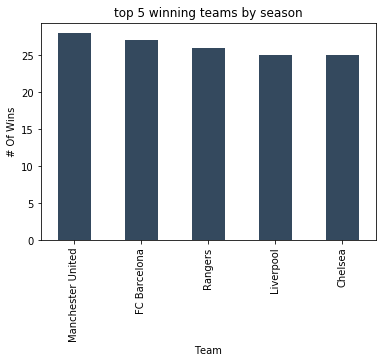

```
2009/2010
```

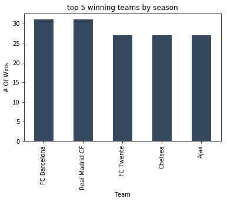

```
2010/2011
```

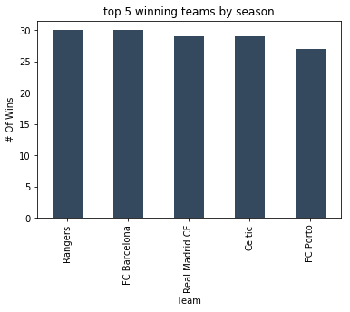

```
2011/2012
```

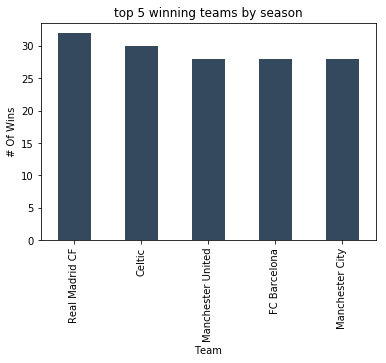

```
2012/2013
```

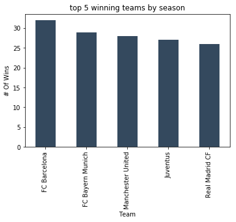

```
2013/2014
```

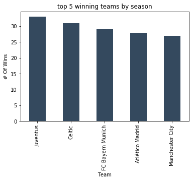

```
2014/2015
```

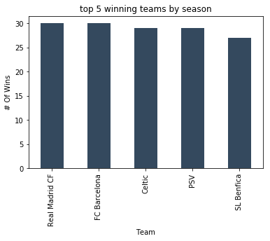

```
2015/2016
```

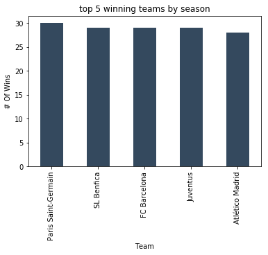

```python
#top 5 teams that achived winning by season graphicaly
for season in seasons:
    df = match_with_teams_names_df[match_with_teams_names_df['season'] == season]
    df = df[df.winner_team != 'draw']
    print(season)
    df.winner_team.value_counts().nlargest(5).plot(kind='bar',color='#34495e')
    plt.title('top 5 winning teams by season')
    plt.xlabel('Team')
    plt.ylabel('# Of Wins')
    plt.show();
```

```python
#adding match_year column to use in merging the table with team_attributes_df table next
match_with_teams_names_df['match_year'] = match_with_teams_names_df['date'].dt.year
```

```python
#adding year column to merge table with match_with_teams_names_df table
team_attributes_df['date'] = pd.to_datetime(team_attributes_df['date'])
team_attributes_df['year'] =team_attributes_df['date'].dt.year
```

```python
matches_years = match_with_teams_names_df['match_year'].unique()
matches_years
```

```
array([2008, 2009, 2010, 2011, 2012, 2013, 2014, 2015, 2016])
```

```python
teams_att_years = team_attributes_df['year'].unique()
teams_att_years = np.sort(teams_att_years)
teams_att_years
```

```
array([2010, 2011, 2012, 2013, 2014, 2015])
```

The `match_with_teams_names_df` contains seasons more than `team_attributes_df` Next We Will Focus seasons In **team_attributes_df**

```python
# A new_df will contain match_with_teams_names_df Rows that in seasons from team_attributes_df
new_df = match_with_teams_names_df[(match_with_teams_names_df['match_year'] >= teams_att_years[0]) & (match_with_teams_names_df['match_year'] < teams_att_years[-1])]
```

```python
new_df.head()
```

|  | id | country_id | league_id | season | date | match_api_id | home_team_api_id | away_team_api_id | home_team_goal | away_team_goal | home_team_name | away_team_name | winner_team | result | match_year |
| --- | --- | --- | --- | --- | --- | --- | --- | --- | --- | --- | --- | --- | --- | --- | --- |
| 376 | 377 | 1 | 1 | 2009/2010 | 2010-02-03 | 665626 | 8635 | 8342 | 3 | 2 | RSC Anderlecht | Club Brugge KV | RSC Anderlecht | H | 2010 |
| 378 | 379 | 1 | 1 | 2009/2010 | 2010-02-04 | 665630 | 9986 | 9985 | 2 | 3 | Sporting Charleroi | Standard de Liège | Standard de Liège | A | 2010 |
| 381 | 382 | 1 | 1 | 2009/2010 | 2010-02-02 | 665634 | 8203 | 9993 | 1 | 0 | KV Mechelen | Beerschot AC | KV Mechelen | H | 2010 |
| 404 | 405 | 1 | 1 | 2009/2010 | 2010-01-30 | 665665 | 8342 | 10001 | 2 | 1 | Club Brugge KV | KVC Westerlo | Club Brugge KV | H | 2010 |
| 405 | 406 | 1 | 1 | 2009/2010 | 2010-01-17 | 665666 | 9985 | 8635 | 0 | 4 | Standard de Liège | RSC Anderlecht | RSC Anderlecht | A | 2010 |

```python
new_df['match_year'].unique()
```

```
array([2010, 2011, 2012, 2013, 2014])
```

```python
seasons =new_df['season'].unique()
seasons
```

```
array(['2009/2010', '2010/2011', '2011/2012', '2012/2013', '2013/2014',
       '2014/2015'], dtype=object)
```

```python
#merging the team_attributes_df with team_df to add the team name to team_attributes_df
team_attributes_df = pd.merge(left=team_attributes_df,right=team_df[['team_api_id','team_long_name']],how='left',left_on='team_api_id',right_on='team_api_id')
```

```python
team_attributes_df.head(1)
```

|  | id | team_fifa_api_id | team_api_id | date | buildUpPlaySpeed | buildUpPlaySpeedClass | buildUpPlayDribbling | buildUpPlayDribblingClass | buildUpPlayPassing | buildUpPlayPassingClass | ... | chanceCreationPositioningClass | defencePressure | defencePressureClass | defenceAggression | defenceAggressionClass | defenceTeamWidth | defenceTeamWidthClass | defenceDefenderLineClass | year | team_long_name |
| --- | --- | --- | --- | --- | --- | --- | --- | --- | --- | --- | --- | --- | --- | --- | --- | --- | --- | --- | --- | --- | --- |
| 0 | 1 | 434 | 9930 | 2010-02-22 | 60 | Balanced | NaN | Little | 50 | Mixed | ... | Organised | 50 | Medium | 55 | Press | 45 | Normal | Cover | 2010 | FC Aarau |

1 rows × 27 columns

```python
team_attributes_df.rename(columns={'team_long_name':'winner_team'},inplace=True)
```

```python
print('Build Up play Speed, build Up Play Passing Speed, Defence Pressure, Defence Aggression and DefenceTeam Width for the top five teams in seasons {} to {}\n'.format(seasons[0],seasons[-1]))
for ind,season in enumerate(seasons):
    print('season',season)
    df = match_with_teams_names_df[match_with_teams_names_df['season'] == season] #filtering match_with_teams_names_df with season
    df = df[df['winner_team'] != 'draw'] #Drop 'draw' From winner_team column to just contain the winner teams' names
    teams = df.winner_team.value_counts().nlargest(5).index #Getting winner teams names
    att_year = seasons[ind].split('/')[1] #getting the year from the season
    att_year = int(att_year) #convert year to int
    att_df = team_attributes_df[team_attributes_df.year == att_year] #creating att_df to get teams attributes from team_attributes_df by the year
    buildUpPlaySpeed =[] #the follwoing lists will carry teams attributes values
    buildUpPlayPassingSpeed =[]
    defencePressure =[]
    defenceAggression =[]
    defenceTeamWidth =[]
    for team in teams: #this for loop will add the teams attributs to the lists
        buildUpPlaySpeed.append(att_df[att_df.winner_team == team]['buildUpPlaySpeed'].values[0])
        buildUpPlayPassingSpeed.append(att_df[att_df.winner_team == team]['buildUpPlayPassing'].values[0])
        defencePressure.append(att_df[att_df.winner_team == team]['defencePressure'].values[0])
        defenceAggression.append(att_df[att_df.winner_team == team]['defenceAggression'].values[0])
        defenceTeamWidth.append(att_df[att_df.winner_team == team]['defenceTeamWidth'].values[0])
    # Here we calculate the mean of each attribut
    buildUpPlaySpeedMean = sum(buildUpPlaySpeed) / len(buildUpPlaySpeed)
    buildUpPlayPassingSpeedMean = sum(buildUpPlayPassingSpeed) / len(buildUpPlayPassingSpeed)
    defencePressureMean = sum(defencePressure) / len(defencePressure)
    defenceAggressionMean = sum(defenceAggression) / len(defenceAggression)
    defenceTeamWidthMean = sum(defenceTeamWidth) / len(defenceTeamWidth)
    # Here we print the results
    print('top teams were',teams.values)
    print('Average Build Up play Speed',buildUpPlaySpeedMean)
    print('Average build Up Play Passing Speed',buildUpPlayPassingSpeedMean)
    print('Average Defence Pressure',defencePressureMean)
    print('Average Defence Aggression',defenceAggressionMean)
    print('Average DefenceTeam Width',defenceTeamWidthMean)
    print(100*'#')
```

```
Build Up play Speed, build Up Play Passing Speed, Defence Pressure, Defence Aggression and DefenceTeam Width for the top five teams in seasons 2009/2010 to 2014/2015

season 2009/2010
top teams were ['FC Barcelona' 'Real Madrid CF' 'FC Twente' 'Chelsea' 'Ajax']
Average Build Up play Speed 45.4
Average build Up Play Passing Speed 36.0
Average Defence Pressure 45.0
Average Defence Aggression 38.0
Average DefenceTeam Width 46.0
####################################################################################################
season 2010/2011
top teams were ['Rangers' 'FC Barcelona' 'Real Madrid CF' 'Celtic' 'FC Porto']
Average Build Up play Speed 50.4
Average build Up Play Passing Speed 41.6
Average Defence Pressure 56.4
Average Defence Aggression 46.8
Average DefenceTeam Width 61.2
####################################################################################################
season 2011/2012
top teams were ['Real Madrid CF' 'Celtic' 'Manchester United' 'FC Barcelona'
 'Manchester City']
Average Build Up play Speed 46.0
Average build Up Play Passing Speed 45.4
Average Defence Pressure 51.0
Average Defence Aggression 56.6
Average DefenceTeam Width 60.8
####################################################################################################
season 2012/2013
top teams were ['FC Barcelona' 'FC Bayern Munich' 'Manchester United' 'Juventus'
 'Real Madrid CF']
Average Build Up play Speed 45.2
Average build Up Play Passing Speed 37.0
Average Defence Pressure 53.4
Average Defence Aggression 56.4
Average DefenceTeam Width 54.8
####################################################################################################
season 2013/2014
top teams were ['Juventus' 'Celtic' 'FC Bayern Munich' 'Atlético Madrid' 'Manchester City']
Average Build Up play Speed 47.8
Average build Up Play Passing Speed 36.8
Average Defence Pressure 45.8
Average Defence Aggression 52.2
Average DefenceTeam Width 49.0
####################################################################################################
season 2014/2015
top teams were ['Real Madrid CF' 'FC Barcelona' 'Celtic' 'PSV' 'SL Benfica']
Average Build Up play Speed 55.2
Average build Up Play Passing Speed 49.2
Average Defence Pressure 54.2
Average Defence Aggression 55.4
Average DefenceTeam Width 57.2
####################################################################################################
```

```
season 2009/2010
```

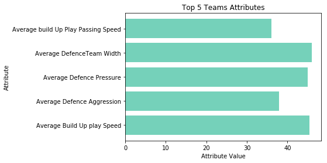

```
####################################################################################################
season 2010/2011
```

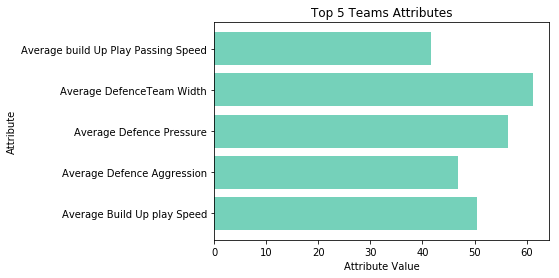

```
####################################################################################################
season 2011/2012
```

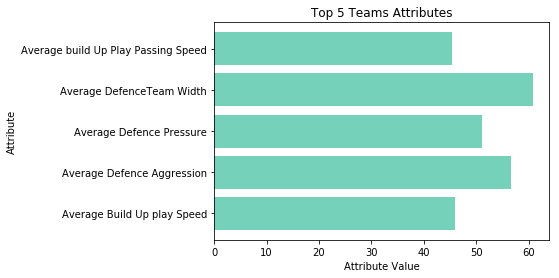

```
####################################################################################################
season 2012/2013
```

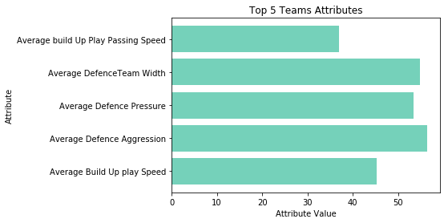

```
####################################################################################################
season 2013/2014
```

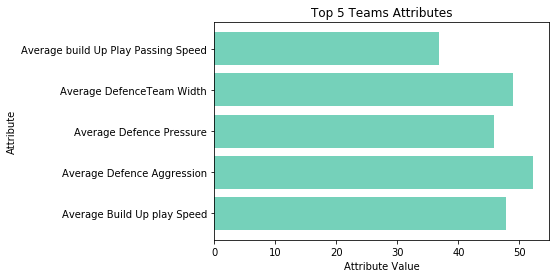

```
####################################################################################################
season 2014/2015
```

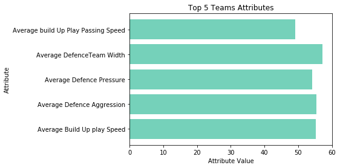

```
####################################################################################################
```

```python
# Here We almost do all what we do in the above cell except printing the results, here we show them with matplotlib.pyplot
for ind,season in enumerate(seasons):
    print('season',season)
    df = match_with_teams_names_df[match_with_teams_names_df['season'] == season]
    df = df[df['winner_team'] != 'draw']
    teams = df.winner_team.value_counts().nlargest(5).index
    att_year = seasons[ind].split('/')[1]
    att_year = int(att_year)
    att_df = team_attributes_df[team_attributes_df.year == att_year]
    buildUpPlaySpeed =[]
    buildUpPlayPassingSpeed =[]
    defencePressure =[]
    defenceAggression =[]
    defenceTeamWidth =[]
    for team in teams:
        buildUpPlaySpeed.append(att_df[att_df.winner_team == team]['buildUpPlaySpeed'].values[0])
        buildUpPlayPassingSpeed.append(att_df[att_df.winner_team == team]['buildUpPlayPassing'].values[0])
        defencePressure.append(att_df[att_df.winner_team == team]['defencePressure'].values[0])
        defenceAggression.append(att_df[att_df.winner_team == team]['defenceAggression'].values[0])
        defenceTeamWidth.append(att_df[att_df.winner_team == team]['defenceTeamWidth'].values[0])
    buildUpPlaySpeedMean = sum(buildUpPlaySpeed) / len(buildUpPlaySpeed)
    buildUpPlayPassingSpeedMean = sum(buildUpPlayPassingSpeed) / len(buildUpPlayPassingSpeed)
    defencePressureMean = sum(defencePressure) / len(defencePressure)
    defenceAggressionMean = sum(defenceAggression) / len(defenceAggression)
    defenceTeamWidthMean = sum(defenceTeamWidth) / len(defenceTeamWidth)
    bars=['Average Build Up play Speed','Average build Up Play Passing Speed','Average Defence Pressure', 'Average Defence Aggression','Average DefenceTeam Width']
    hights=[buildUpPlaySpeedMean,buildUpPlayPassingSpeedMean,defencePressureMean,defenceAggressionMean,defenceTeamWidthMean]
    plt.barh(bars,hights, color=(0.4, 0.8, 0.7, 0.9))
    plt.title('Top 5 Teams Attributes')
    plt.xlabel('Attribute Value')
    plt.ylabel('Attribute')
    plt.show();
    print(100*'#')
```

> Lets go to the second part of our analysis

```python
match_with_teams_names_df.head(1)
```

|  | id | country_id | league_id | season | date | match_api_id | home_team_api_id | away_team_api_id | home_team_goal | away_team_goal | home_team_name | away_team_name | winner_team | result | match_year |
| --- | --- | --- | --- | --- | --- | --- | --- | --- | --- | --- | --- | --- | --- | --- | --- |
| 0 | 1 | 1 | 1 | 2008/2009 | 2008-08-17 | 492473 | 9987 | 9993 | 1 | 1 | KRC Genk | Beerschot AC | draw | D | 2008 |

```python
league_df.head(1)
```

|  | id | country_id | name |
| --- | --- | --- | --- |
| 0 | 1 | 1 | Belgium Jupiler League |

```python
# Here we merging match_with_teams_names_df with league_df to get columns we will work with
lega_mathes_df = pd.merge(left=match_with_teams_names_df[['country_id','season','home_team_goal','away_team_goal']],right=league_df[['country_id','name']],how='left',on='country_id')
lega_mathes_df.head(1)
```

|  | country_id | season | home_team_goal | away_team_goal | name |
| --- | --- | --- | --- | --- | --- |
| 0 | 1 | 2008/2009 | 1 | 1 | Belgium Jupiler League |

```python
# Here we sum the home and away teams total goals for each league
lega_df = lega_mathes_df.groupby('name',as_index=False)['home_team_goal','away_team_goal'].sum()
lega_df['total_goals'] = lega_df.home_team_goal + lega_df.away_team_goal
lega_df
```

|  | name | home_team_goal | away_team_goal | total_goals |
| --- | --- | --- | --- | --- |
| 0 | Belgium Jupiler League | 2781 | 2060 | 4841 |
| 1 | England Premier League | 4715 | 3525 | 8240 |
| 2 | France Ligue 1 | 4265 | 3162 | 7427 |
| 3 | Germany 1. Bundesliga | 3982 | 3121 | 7103 |
| 4 | Italy Serie A | 4528 | 3367 | 7895 |
| 5 | Netherlands Eredivisie | 4357 | 3185 | 7542 |
| 6 | Poland Ekstraklasa | 2678 | 1978 | 4656 |
| 7 | Portugal Liga ZON Sagres | 2890 | 2311 | 5201 |
| 8 | Scotland Premier League | 2607 | 2197 | 4804 |
| 9 | Spain LIGA BBVA | 4959 | 3453 | 8412 |
| 10 | Switzerland Super League | 2365 | 1801 | 4166 |

```python
# Here we take alook at the description statistics of our data
lega_df.describe()
```

|  | home_team_goal | away_team_goal | total_goals |
| --- | --- | --- | --- |
| count | 11.000000 | 11.000000 | 11.000000 |
| mean | 3647.909091 | 2741.818182 | 6389.727273 |
| std | 980.992299 | 666.529192 | 1642.202794 |
| min | 2365.000000 | 1801.000000 | 4166.000000 |
| 25% | 2729.500000 | 2128.500000 | 4822.500000 |
| 50% | 3982.000000 | 3121.000000 | 7103.000000 |
| 75% | 4442.500000 | 3276.000000 | 7718.500000 |
| max | 4959.000000 | 3525.000000 | 8412.000000 |

> Here of courese we can see the big difference between the home and the away team total goals

###### next cells we show teams total goals graphically

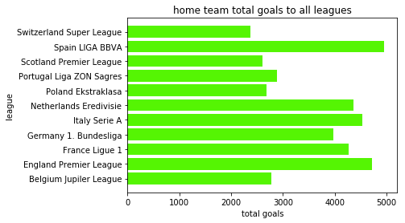

```python
plt.barh(lega_df.name,lega_df.home_team_goal,color='#55f503')
plt.title('home team total goals to all leagues')
plt.xlabel('total goals')
plt.ylabel('league');
```

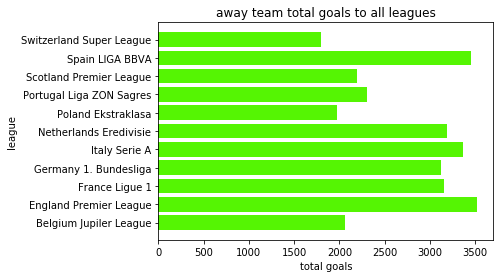

```python
plt.barh(lega_df.name,lega_df.away_team_goal,color='#55f503')
plt.title('away team total goals to all leagues')
plt.xlabel('total goals')
plt.ylabel('league');
```

```
''
```

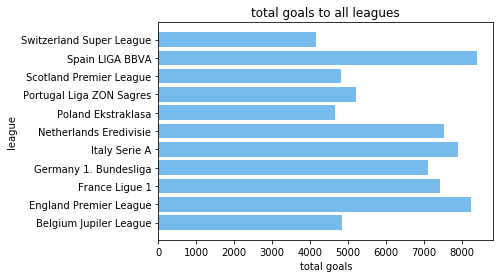

```python
plt.barh(lega_df.name,lega_df.total_goals,color='#77bbec')
plt.title('total goals to all leagues')
plt.xlabel('total goals')
plt.ylabel('league')
;
```

> we can see a significant difference between the average number of goals scored by the home team **(3648)** and the away team**(2742)**,This means that when you play at home, you are likely to score the most goals and of course win

> Now Lets See The Last Part

```python
player_attributes_df.head(1)
```

|  | id | player_fifa_api_id | player_api_id | date | overall_rating | potential | preferred_foot | attacking_work_rate | defensive_work_rate | crossing | ... | vision | penalties | marking | standing_tackle | sliding_tackle | gk_diving | gk_handling | gk_kicking | gk_positioning | gk_reflexes |
| --- | --- | --- | --- | --- | --- | --- | --- | --- | --- | --- | --- | --- | --- | --- | --- | --- | --- | --- | --- | --- | --- |
| 0 | 1 | 218353 | 505942 | 2016-02-18 00:00:00 | 67.0 | 71.0 | right | medium | medium | 49.0 | ... | 54.0 | 48.0 | 65.0 | 69.0 | 69.0 | 6.0 | 11.0 | 10.0 | 8.0 | 8.0 |

1 rows × 42 columns

```python
# Here we get highest ability players
top_players = player_attributes_df[player_attributes_df['potential'] >= 80]
```

```python
# Here we get the attributes only from player_attributes_df
players_att= top_players.iloc[:,6:]
```

```python
players_att.head()
```

|  | preferred_foot | attacking_work_rate | defensive_work_rate | crossing | finishing | heading_accuracy | short_passing | volleys | dribbling | curve | ... | vision | penalties | marking | standing_tackle | sliding_tackle | gk_diving | gk_handling | gk_kicking | gk_positioning | gk_reflexes |
| --- | --- | --- | --- | --- | --- | --- | --- | --- | --- | --- | --- | --- | --- | --- | --- | --- | --- | --- | --- | --- | --- |
| 24 | left | medium | medium | 77.0 | 50.0 | 50.0 | 64.0 | 28.0 | 65.0 | 65.0 | ... | 58.0 | 58.0 | 72.0 | 72.0 | 72.0 | 13.0 | 6.0 | 8.0 | 8.0 | 11.0 |
| 25 | left | medium | medium | 77.0 | 50.0 | 50.0 | 64.0 | 28.0 | 65.0 | 65.0 | ... | 58.0 | 58.0 | 72.0 | 72.0 | 72.0 | 13.0 | 6.0 | 8.0 | 8.0 | 11.0 |
| 26 | left | medium | medium | 77.0 | 50.0 | 50.0 | 64.0 | 28.0 | 65.0 | 65.0 | ... | 58.0 | 58.0 | 72.0 | 72.0 | 72.0 | 13.0 | 6.0 | 8.0 | 8.0 | 11.0 |
| 27 | left | medium | medium | 77.0 | 50.0 | 50.0 | 64.0 | 28.0 | 65.0 | 65.0 | ... | 58.0 | 58.0 | 72.0 | 72.0 | 72.0 | 13.0 | 6.0 | 8.0 | 8.0 | 11.0 |
| 28 | left | medium | medium | 77.0 | 50.0 | 50.0 | 64.0 | 28.0 | 65.0 | 65.0 | ... | 58.0 | 58.0 | 72.0 | 72.0 | 72.0 | 13.0 | 6.0 | 8.0 | 8.0 | 11.0 |

5 rows × 36 columns

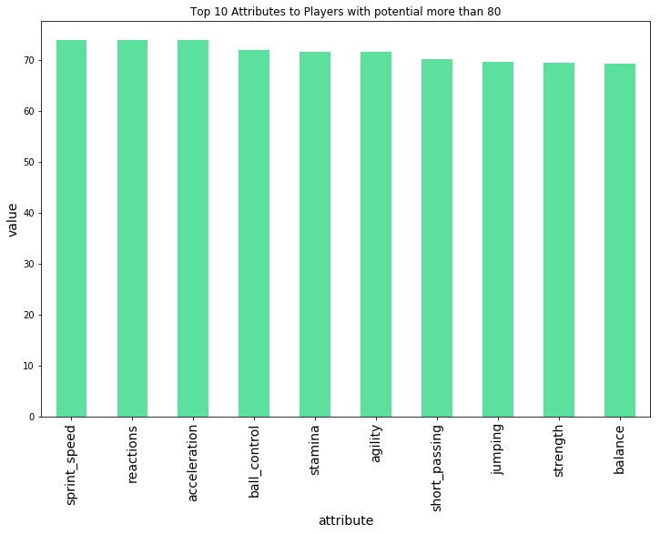

```python
# Here we get the top 10 attributes of the top players
players_att.mean().sort_values().nlargest(10).plot(kind='bar',figsize=(12,8),color='#5ce09e')
plt.title('Top 10 Attributes to Players with potential more than 80')
plt.xlabel('attribute',fontsize=14)
plt.xticks(fontsize=14)
plt.ylabel('value',fontsize=14)
plt.show();
```

> The Top 10 Attribuets Of Players With potential More Than Or Equal to 80 Are : **`1-Sprint Speed 2-Reactions 3-Acceleration 4-Ball Control 5-Stamina 6-Agility 7-Short Passing 8-Jumping 9-Strength 10-Balance`**

## Limitations

There are some limitations which arise due the data in question.

> In the match table there are seasons more than seasons in team attribute table the presence of these seasons will enhance the data analysis

> There are lot of columns in the tables for example Match table has 115 columns most of them meaning less.

## Conclusions

### Who is a Candidated to Win Home and Away Team Based on Total Goals?

> we can see a significant difference between the average number of goals scored by the home team **(3648)** and the away team**(2742)**,This means that when you play at home, you are likely to score the most goals and of course win

### What Are The Top 10 Attributes Of Top Players?

> The Top 10 Attribuets Of Players With potential More Than Or Equal to 80 Are : **`1-Sprint Speed 2-Reactions 3-Acceleration 4-Ball Control 5-Stamina 6-Agility 7-Short Passing 8-Jumping 9-Strength 10-Balance`**

```python
from subprocess import call
call(['python', '-m', 'nbconvert', 'Investigate_a_Dataset.ipynb'])
```

```
0
```